# Implementing Buetti et al(2019)

ADF Clarke

24/08/2020

# Data Import and Overview

## Importing

We start by writing a function to import a study from the excel file, and remove error trials.

```r
import_experiment <- function(sheet, d_labels, exp_number, exp_part) {

    read_excel(
      "../previous_work/Buetti2019_data_code/OSF_originaldata.xlsx",
      sheet = sheet) %>%
    # use tidier variable names
    select(
        p_id = "Subject",
        trial = "Trial",
        t_id = "tid",
        N_T = "numd",
        d_feature = "dcolors",
        rt = "RT",
        response = "resp",
        error = "Error") %>%
    # code up p_id, t_id and distracter colour as a factor
    mutate(
        exp_id = paste(exp_number, exp_part, sep = ""),
        p_id = as_factor(p_id),
        d_feature = as_factor(d_feature),
        d_feature = fct_recode(d_feature, !!!d_labels),
        t_id = as_factor(t_id),
        t_id = fct_recode(t_id, left = "0", right = "1")) %>%
    # remove error trials
    filter(error == 0) -> d

    return(d)
}
```

We can now import all experiments:

Anna, want to tidy this up so we can map it all?

```r
d <- list()

d$e1a <- import_experiment(2,  c(orange = "1", blue = "2", yellow = "3"), 1, "a")
d$e1b <- import_experiment(4,  c(diamond = "1", circle = "2", triangle = "3"), 1, "b")
d$e2a <- import_experiment(6,  c(`orange diamond` = "1", `blue circle` = "2", `yellow triangle` = "3"), 2, "a")
d$e2b <- import_experiment(8,  c(`orange circle` = "1", `yellow diamond` = "2", `blue triangle` = "3"), 2, "b")
d$e2c <- import_experiment(10, c(`blue diamond` = "1", `yellow circle` = "2", `orange triangle` = "3"), 2, "c")
d$e3a <- import_experiment(12, c(orange = "1", blue = "2", yellow = "3"), 3, "a")
d$e3b <- import_experiment(14, c(diamond = "1", circle = "2", semicircle = "3"), 3, "b")
d$e4a <- import_experiment(16, c(`orange diamond` = "1", `blue circle` = "2", `yellow semicircle` = "3"), 4, "a")
d$e4b <- import_experiment(18, c(`orange circle` = "1", `yellow diamond` = "2", `blue semicircle` = "3"), 4, "b")
d$e4c <- import_experiment(20, c(`blue diamond` = "1", `yellow circle` = "2", `orange semicircle` = "3"), 4, "c")

d <- bind_rows(d)
```

# Computational Replication of Buetti et al (2019)

Before doing anything else (i.e., new), we want to confirm that we can replicate the original analysis.

## Calculating $D$

This function calculates the search slopes ($D$), for rt against log($N_T+1$) for a sub-experiment.

```r
account_for_zero_distracters <- function(df)
{
  # Little helper function to sort out the quirk with N_T = 0
  # i.e, in this case, d_feature is undefined
  # So, well, copy this row three times - once for each value of d_feature
  bind_rows(
    filter(df, N_T==0) %>% mutate(d_feature = levels(df$d_feature)[2]),
    filter(df, N_T==0) %>% mutate(d_feature = levels(df$d_feature)[3]),
    filter(df, N_T==0) %>% mutate(d_feature = levels(df$d_feature)[4]),
    filter(df, N_T>0)) %>%
    mutate(d_feature = as_factor(d_feature)) -> df

  return(df)
}
calc_D_per_feature <- function(experiment, df) {

  df %>%
    filter(exp_id == experiment) %>%
    group_by(exp_id, p_id, d_feature, N_T) %>%
    summarise(mean_rt = mean(rt), .groups = "drop") %>%
    mutate(d_feature = fct_drop(d_feature)) -> df

  df <- account_for_zero_distracters(df)

  m <- lm(mean_rt ~  0 + d_feature + log(N_T+1):d_feature, df)
  coef_tab <- summary(m)$coefficients

  d_out <- tibble(
    exp_id = experiment,
    d_feature = levels(df$d_feature),
    D = c(coef_tab[4:6,1]))

  return(d_out)
}
```

We can now run this over all the experiments:

```r
exp_D <- map_dfr(unique(d$exp_id), calc_D_per_feature, d)
```

## Predicing $D$

```r
predict_D_overall <- function(f, D)
{
  # f is a feature condition, such as "blue circle"
  # D is the dataframe that is output by calc_D_per_feature
  f1 <- word(f, 1)
  f2 <- word(f, 2)

  D1 = as.numeric(filter(D, d_feature == f1)$D)
  D2 = as.numeric(filter(D, d_feature == f2)$D)

  D_collinear = 1/((1/D1) + (1/D2))
  D_best_feature = min(D1, D2)
  D_orth_contrast =  sqrt(1/((1/D1^2) + (1/D2^2)))

  return(list(
    "best feature" = D_best_feature,
    "orthog. contrast" = D_orth_contrast,
    "collinear" = D_collinear))
}

gen_exp_predictions <- function(e_id)
{
  # Predict values of D for composite features

  df <- filter(d, exp_id == e_id) %>%
  mutate(d_feature = fct_drop(d_feature))

  e_n = parse_number(e_id)
  D <- filter(exp_D, parse_number(exp_id) == e_n - 1)

  d_out <- tibble(
    exp_id = e_id,
    d_feature = levels(df$d_feature)[2:4],
    map_dfr(levels(df$d_feature)[2:4], predict_D_overall, D))

  return(d_out)
}
```

We can now predict values of $D$ for all experiments 2x and 4x.

```r
pred_D <- map_df(c("2a", "2b", "2c", "4a", "4b", "4c"), gen_exp_predictions)
```

Now, recreate the scatter plots from Buetti et al (2019), Figure 4.

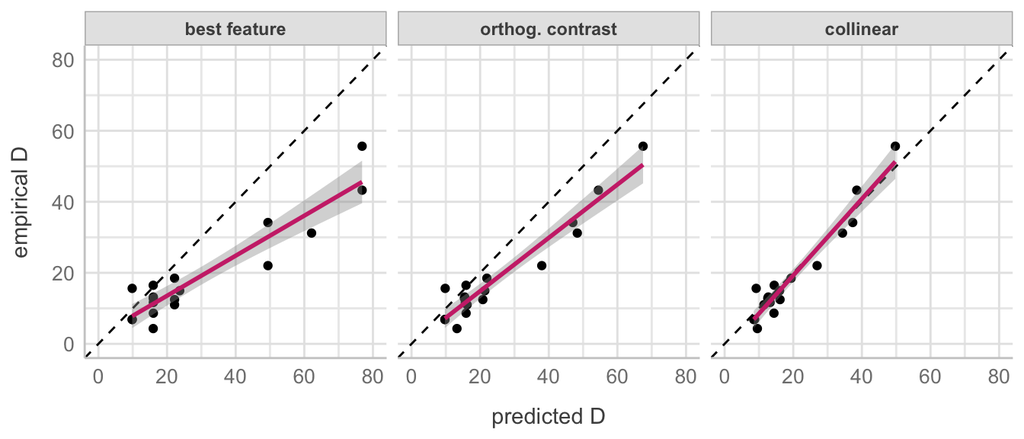

Computational replication of Figure 4 (top row) from Buetti et al (2019).

```r
left_join(pred_D, exp_D, by = c("exp_id", "d_feature")) %>%
  pivot_longer(
    cols = c(`best feature`, `orthog. contrast`, collinear),
    values_to = "D_pred",
    names_to = "method") %>%
  mutate(method = fct_relevel(method, "best feature", "orthog. contrast")) %>%
  ggplot(aes(x = D_pred, y = D)) +
  geom_point() +
  geom_abline(linetype = 2) +
  geom_smooth(method = "lm", formula = y ~ x, colour = "violetred3") +
  coord_cartesian(xlim = c(0, 80), ylim = c(0, 80)) +
  facet_wrap(~ method) +
  see::theme_lucid() +
  scale_x_continuous("predicted D") +
  scale_y_continuous("empirical D")
```